# NPS - Exploratory analysis in R - Text analysis

Nitin Ahuja

2017-10-22

# NPS analysis

## NPS - Comment analysis

In an [previous post]({{% ref "2017-08-28-nps-exploratory-analysis-in-r.html" %}}) we performed some EDA on the NPS data we have. Recall that as part of the question about the likelihood of recommending a service or business there is an optional text response about **why** they picked this score.

Let’s try and see what those responses are all about. We had already performed some sentiment analysis on this text we are now going to attempt to classify this text into topics. Topic modeling is a method for **unsupervised classification** of such documents, similar to clustering on numeric data, which finds natural groups of items even when we’re not sure what we’re looking for.

Latent Dirichlet allocation (LDA) is a particularly popular method for fitting a topic model. It treats each document as a mixture of topics, and each topic as a mixture of words.

LDA has two key tenets - Every document is a mixture of topics - Every topic is a mixture of words.

In our NPS comment data, we will treat each comment as a document and we’ll try and see how many topics we can identify. Since LDA is unsupervised classification, and we do not have any a priori knowledge of the possible number of topics, we’ll need to do some trial and error.

Let’s start by loading the required libraries

```r
library(irlba)

library(tidytext)
library(topicmodels)
library(ggplot2)

library(tidyr)
library(dplyr)
library(RColorBrewer)
library(lubridate)
library(stringr)

library(widyr)
library(broom)

library(tidygraph)
library(ggraph)
library(ggrepel)
```

LDA needs a term document matrix, let’s start by reading in the data and remove the rows that do not have any comments.

```r
nps <- read.csv('~/data/nps.csv', header = TRUE, quote = '"'
                , na.strings=c("", "NA", "#N/A")
                , colClasses = c("Feedback.Received"= "Date"
                               , "Comment"="character"
                               , "Survey.Sent"="Date"
                               , "TPY"="integer"
                               ))
nps<- nps %>% drop_na(Comment)
```

That leaves us with 1130 rows.

Let’s also enrich the data with some additional fields and add the category like we did in the last post. The category is dependent on the score and scores from 0 through 6 are considered *detractors*, 7 - 8 are *passives* and 9 and 10 are *promorters*.

```r
nps$year <- as.factor(year(nps$Received))
nps$month <- cut(nps$Received, breaks = "month")
nps$days <- nps$Received - nps$Sent
nps$weekday <- weekdays(nps$Received)
nps$weekday <- factor(nps$weekday, levels = c("Sunday", "Monday","Tuesday", "Wednesday", "Thursday", "Friday", "Saturday"))
nps$cat <- cut(nps$Score, breaks = c(-1,6,8,10), labels = c("Detractor", "Passive", "Promoter"))
```

Extract out the comments while keeping the category

```r
comments <- nps %>%
  select(Comment, cat) %>%
  group_by(row_number())
```

### LDA using per comment as a document

The LDA function takes a TermDocumentMatrix object as an input; let’s convert our text into a DFM

```r
nps_count <- comments %>%
  unnest_tokens(word, Comment) %>%
  anti_join(stop_words, by = c('word')) %>%
  count(`row_number()`, word, sort = TRUE) %>%
  ungroup()
```

Now convert to a DTM and perform the LDA

```r
nps_dtm <- nps_count %>%
  cast_dtm(`row_number()`, word, n)
```

```r
topic_count <- 25
nps_lda <- LDA(nps_dtm, k = topic_count, control = list(seed=1234))
nps_topics <- tidy(nps_lda, matrix = "beta")
```

Next - let’s find out the top 5 words per topic and plot those.

```r
top_terms <- nps_topics %>%
  group_by(topic) %>%
  top_n(5, beta) %>%
  ungroup() %>%
  arrange(topic, -beta)
```

Plot the terms and topics.

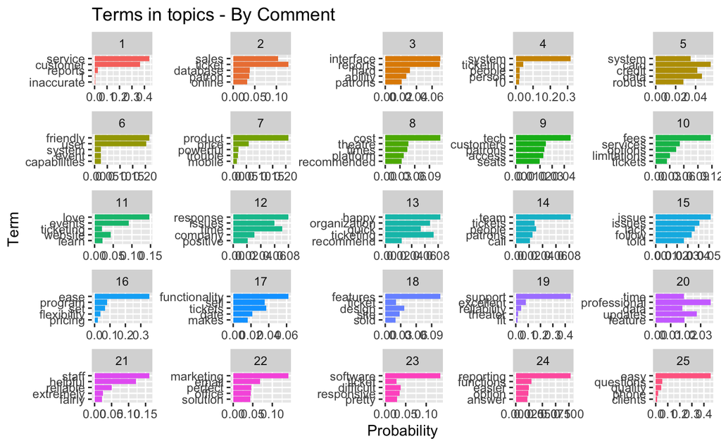

```r
top_terms %>%
  mutate(term = reorder(term, beta)) %>%
  ggplot(aes(term, beta, fill=factor(topic))) +
  geom_col(show.legend = FALSE) +
  facet_wrap(~ topic, scales = "free" ) +
  coord_flip() +
  guides(fill=FALSE) +
  labs(title = "Terms in topics - By Comment", x = "Term", y = "Probability")
```